# Bookdown

# Bookdown

## 要求

安装 *R* 和 *bookdown* 包

# 介绍

*Bookdown* 解决以下问题：

- 如何对公式，理论，图表和交叉引用进行排版
- 如何产生多种输出格式
- 如何一般化书的模板
- 编译器支持
- 如何出版书

## 动机

使书更加容易阅读，一些写书的框架也不错，例如 [Gitbook](https://www.gitbook.com)，[Tufte CSS](http://edwardtufte.github.io/tufte-css/),[Tufte-LaTeX](https://tufte-latex.github.io/tufte-latex/))

## 开始

最简单的方式就是从一个demo开始，通过以下步骤：

- 下载这个demo
- 安装 *Rstudio*
- 安装 *bookdown*
- 打开demo的文件夹，点击 `bookdown-demo.Rproj`的文件
- 打开 `index.Rmd` 文件，点击 `Build book`

## 使用方法

在demo例子中，我们有这些文件：

- index.Rmd
- 01-intro.Rmd
- 02-literature.Rmd
- 03-method.Rmd
- 04-application.Rmd
- 05-summary.Rmd

*bookdown* 将这些 *Rmd* 文件按照文件顺序进行融合，例如 *01-intro.Rmd* 和 *02-literature.Rmd*, 文件带有下划线 `_` 将被忽略，如果有 `index.Rmd` 文件，则 `index.html`将从这个文件产生。也可以通过 `_bookdown.yml`文件进行配置，可以通过`rmd_files`来实现配置：

```
rmd_files: ["index.Rmd", "abstract.Rmd", "intro.Rmd"]
```

加入你需要多种输出结果，可以使用下面的命令：

```
rmd_files:
  html: ["index.Rmd", "abstract.Rmd", "intro.Rmd"]
  latex: ["abstract.Rmd", "intro.Rmd"]
```

可以选择多种输出格式：

```
bookdown::render_book("foo.Rmd", "bookdown::gitbook")
bookdown::render_book("foo.Rmd", "bookdown::pdf_book")
bookdown::render_book("foo.Rmd", bookdown::gitbook(lib_dir = "libs"))
bookdown::render_book("foo.Rmd", bookdown::pdf_book(keep_tex = TRUE))
```

可以定义一个`YAML field`叫做`site`，并赋值 `bookdown::bookdown_site`，输出格式在 `output` 定义：

```
---
site: "bookdown::bookdown_site"
output:
  bookdown::gitbook:
    lib_dir: "book_assets"
  bookdown::pdf_book:
    keep_tex: yes
---
```

可以使用`Build book`和`Knit`按钮来编译当前章节。

更多关于`_bookdown.yml`在后面介绍，这里只是一个简单的例子

```
---
title: "Authoring A Book with R Markdown"
author: "Yihui Xie"
date: "2019-04-17"
site: "bookdown::bookdown_site"
output:
  bookdown::gitbook: default
documentclass: book
bibliography: ["book.bib", "packages.bib"]
biblio-style: apalike
link-citations: yes
---
```

## 两种编译方法

对于编译，有两种方式。第一种是`Merge and Knit`(M-K)，即先合并再转化，另外一种是`Knit and Merge`(K-M)，即先转化在合并。一般来说，编译默认的方式是M-K，如果需要转化为K-M，使用`render_book()`函数时使用`new_session = TRUE`，或者在`_bookdown.ylm`文件中加入 `new_session: yes`

## 一些小的建议

- 编译成*PDF*文件比较耗时，所以建议先编译成为`HTML`格式，版本确定之后，再转化成为*PDF*
- 因为编译时候，有程序运行，所以建议加上`cache = TRUE`：

````
\```{r important-computing, cache=TRUE}
````

# 组成

这一章主要介绍`Pandoc`的一些使用，就是`Markdown`的内容

- *text*：`_text_` 或者 `*text*`
- **text**: `__text__` 或者 `**text**`
- H<sub>2</sub>SO<sub>4</sub>: `H~2~SO~4~`
- Fe<sup>2+</sup>: `Fe^2+^`
- Small Caps: `<span style="font-variant:small-caps;">Small Caps</span>`
- 插入图片：`![alt text or image title](path/to/image)`
- 脚注：`^[This is a footnote.]`

## 公式

```
\begin{equation}
  f\left(k\right) = \binom{n}{k} p^k\left(1-p\right)^{n-k}
  (\#eq:binom)
\end{equation}
```

公式如下：
$$\begin{equation}
f\left(k\right) = \binom{n}{k} p^k\left(1-p\right)^{n-k}
(\#eq:binom)
\end{equation}$$

如果要引用公式 `\@ref(eq:binom)`

## 理论和证明

由于这部分文件比较特殊，可以看[这里](https://bookdown.org/yihui/bookdown/markdown-extensions-by-bookdown.html)

```
Here is my theorem.
```

```
For a right triangle, if $c$ denotes the length of the hypotenuse
and $a$ and $b$ denote the lengths of the other two sides, we have

$$a^2 + b^2 = c^2$$
```

## 图

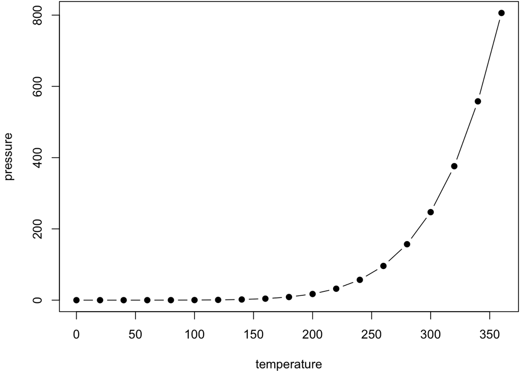

```r
par(mar = c(4, 4, 0.1, 0.1))
plot(pressure, pch = 19, type = "b")
```

## 表

```r
knitr::kable(
  head(mtcars[, 1:8], 10), booktabs = TRUE,
  caption = 'A table of the first 10 rows of the mtcars data.'
)
```

A table of the first 10 rows of the mtcars data.

|  | mpg | cyl | disp | hp | drat | wt | qsec | vs |
| --- | --- | --- | --- | --- | --- | --- | --- | --- |
| Mazda RX4 | 21.0 | 6 | 160.0 | 110 | 3.90 | 2.620 | 16.46 | 0 |
| Mazda RX4 Wag | 21.0 | 6 | 160.0 | 110 | 3.90 | 2.875 | 17.02 | 0 |
| Datsun 710 | 22.8 | 4 | 108.0 | 93 | 3.85 | 2.320 | 18.61 | 1 |
| Hornet 4 Drive | 21.4 | 6 | 258.0 | 110 | 3.08 | 3.215 | 19.44 | 1 |
| Hornet Sportabout | 18.7 | 8 | 360.0 | 175 | 3.15 | 3.440 | 17.02 | 0 |
| Valiant | 18.1 | 6 | 225.0 | 105 | 2.76 | 3.460 | 20.22 | 1 |
| Duster 360 | 14.3 | 8 | 360.0 | 245 | 3.21 | 3.570 | 15.84 | 0 |
| Merc 240D | 24.4 | 4 | 146.7 | 62 | 3.69 | 3.190 | 20.00 | 1 |
| Merc 230 | 22.8 | 4 | 140.8 | 95 | 3.92 | 3.150 | 22.90 | 1 |
| Merc 280 | 19.2 | 6 | 167.6 | 123 | 3.92 | 3.440 | 18.30 | 1 |

### 多张表

```r
knitr::kable(
  list(
    head(iris[, 1:2], 3),
    head(mtcars[, 1:3], 5)
  ),
  caption = 'A Tale of Two Tables.', booktabs = TRUE
)
```

A Tale of Two Tables.

| Sepal.Length | Sepal.Width |
| --- | --- |
| 5.1 | 3.5 |
| 4.9 | 3.0 |
| 4.7 | 3.2 |

|  | mpg | cyl | disp |
| --- | --- | --- | --- |
| Mazda RX4 | 21.0 | 6 | 160 |
| Mazda RX4 Wag | 21.0 | 6 | 160 |
| Datsun 710 | 22.8 | 4 | 108 |
| Hornet 4 Drive | 21.4 | 6 | 258 |
| Hornet Sportabout | 18.7 | 8 | 360 |

### 长表

如果是比较长的表，需要进行分页，需要用到`longtable = TRUE`，并且使用`\usepackage{longtable}`在 *LaTeX* preamble 文件中

```r
knitr::kable(
  iris[1:55, ], longtable = TRUE, booktabs = TRUE,
  caption = 'A table generated by the longtable package.'
)
```

A table generated by the longtable package.

| Sepal.Length | Sepal.Width | Petal.Length | Petal.Width | Species |
| --- | --- | --- | --- | --- |
| 5.1 | 3.5 | 1.4 | 0.2 | setosa |
| 4.9 | 3.0 | 1.4 | 0.2 | setosa |
| 4.7 | 3.2 | 1.3 | 0.2 | setosa |
| 4.6 | 3.1 | 1.5 | 0.2 | setosa |
| 5.0 | 3.6 | 1.4 | 0.2 | setosa |
| 5.4 | 3.9 | 1.7 | 0.4 | setosa |
| 4.6 | 3.4 | 1.4 | 0.3 | setosa |
| 5.0 | 3.4 | 1.5 | 0.2 | setosa |
| 4.4 | 2.9 | 1.4 | 0.2 | setosa |
| 4.9 | 3.1 | 1.5 | 0.1 | setosa |
| 5.4 | 3.7 | 1.5 | 0.2 | setosa |
| 4.8 | 3.4 | 1.6 | 0.2 | setosa |
| 4.8 | 3.0 | 1.4 | 0.1 | setosa |
| 4.3 | 3.0 | 1.1 | 0.1 | setosa |
| 5.8 | 4.0 | 1.2 | 0.2 | setosa |
| 5.7 | 4.4 | 1.5 | 0.4 | setosa |
| 5.4 | 3.9 | 1.3 | 0.4 | setosa |
| 5.1 | 3.5 | 1.4 | 0.3 | setosa |
| 5.7 | 3.8 | 1.7 | 0.3 | setosa |
| 5.1 | 3.8 | 1.5 | 0.3 | setosa |
| 5.4 | 3.4 | 1.7 | 0.2 | setosa |
| 5.1 | 3.7 | 1.5 | 0.4 | setosa |
| 4.6 | 3.6 | 1.0 | 0.2 | setosa |
| 5.1 | 3.3 | 1.7 | 0.5 | setosa |
| 4.8 | 3.4 | 1.9 | 0.2 | setosa |
| 5.0 | 3.0 | 1.6 | 0.2 | setosa |
| 5.0 | 3.4 | 1.6 | 0.4 | setosa |
| 5.2 | 3.5 | 1.5 | 0.2 | setosa |
| 5.2 | 3.4 | 1.4 | 0.2 | setosa |
| 4.7 | 3.2 | 1.6 | 0.2 | setosa |
| 4.8 | 3.1 | 1.6 | 0.2 | setosa |
| 5.4 | 3.4 | 1.5 | 0.4 | setosa |
| 5.2 | 4.1 | 1.5 | 0.1 | setosa |
| 5.5 | 4.2 | 1.4 | 0.2 | setosa |
| 4.9 | 3.1 | 1.5 | 0.2 | setosa |
| 5.0 | 3.2 | 1.2 | 0.2 | setosa |
| 5.5 | 3.5 | 1.3 | 0.2 | setosa |
| 4.9 | 3.6 | 1.4 | 0.1 | setosa |
| 4.4 | 3.0 | 1.3 | 0.2 | setosa |
| 5.1 | 3.4 | 1.5 | 0.2 | setosa |
| 5.0 | 3.5 | 1.3 | 0.3 | setosa |
| 4.5 | 2.3 | 1.3 | 0.3 | setosa |
| 4.4 | 3.2 | 1.3 | 0.2 | setosa |
| 5.0 | 3.5 | 1.6 | 0.6 | setosa |
| 5.1 | 3.8 | 1.9 | 0.4 | setosa |
| 4.8 | 3.0 | 1.4 | 0.3 | setosa |
| 5.1 | 3.8 | 1.6 | 0.2 | setosa |
| 4.6 | 3.2 | 1.4 | 0.2 | setosa |
| 5.3 | 3.7 | 1.5 | 0.2 | setosa |
| 5.0 | 3.3 | 1.4 | 0.2 | setosa |
| 7.0 | 3.2 | 4.7 | 1.4 | versicolor |
| 6.4 | 3.2 | 4.5 | 1.5 | versicolor |
| 6.9 | 3.1 | 4.9 | 1.5 | versicolor |
| 5.5 | 2.3 | 4.0 | 1.3 | versicolor |
| 6.5 | 2.8 | 4.6 | 1.5 | versicolor |

## 交叉引用

使用命令`\@ref(label)`，*Pandoc* 将会对标题产生一个ID，例如 `# Hello World`，可以使用ID `hello-world`

## 区块

使用`{block}`来实现

Some text for this block.

## 引用

可以将引用写入`.bib`文件，使用BibTex, BibTex文件如下：

```
@Manual{R-base,
  title = {R: A Language and Environment for Statistical
    Computing},
  author = {{R Core Team}},
  organization = {R Foundation for Statistical Computing},
  address = {Vienna, Austria},
  year = {2016},
  url = {https://www.R-project.org/},
}
```

引用方式：@key ( in Latex) 或 [@key] ()

## HTML插件

R语言长处在于它的可视化，通过`htmlwidgets`的包可以使用一些Javascript插件，由于PDF格式不支持JS插件，所以需要使用一个包 *webshot* 来将JS截成一张静态图片，这个包是基于 *Phantomjs*的

```
install.packages("webshot")
webshot::install_phantomjs()
```